# A Parsimonious Approach to Gerrymandering Analysis (Tennessee)

1. Joseph Holler (josephh@middlebury.edu; corresponding author), Middlebury College

2. Peter Kedron (peterkedron@ucsb.edu), University of California, Santa Barbara

3. Pyung Kim (pyungkim@ucsb.edu), University of California, Santa Barbara

2026-08-26

# Abstract

This is a study of gerrymandering in the United States. We introduce a parsimonious composite approach that compares each district’s racial and partisan composition to that of compact reference shapes. We implement the entire workflow so that it can be applied to any U.S. state from standard, publicly available data.

## Study Metadata

- `Key words`: gerrymandering, compactness, convex hull, racial and partisan representation
- `Subject`: Social and Behavioral Sciences: Geography: Geographic Information Sciences
- `Date created`: 2025-02-17
- `Date modified`: 2026-08-26
- `Spatial Coverage`: United States; one state per run, selected via `params$state` (this run: Tennessee)
- `Spatial Resolution`: Census block groups (demographics) and voting precincts (elections)
- `Spatial Reference System`: EPSG:4269 NAD 1983 Geographic Coordinate System
- `Temporal Coverage`: 2020 decennial census population; 2024 presidential election results
- `Temporal Resolution`: Decennial census

# 1 Study design

## 1.1 Overview

This is an original, exploratory study based on the literature on gerrymandering metrics. We evaluate the usefulness of a new gerrymandering metric that measures how much a congressional district’s representativeness differs from that of compact reference shapes derived from it. These reference shapes are its convex hull, its minimum bounding circle, and a compact district grown from its population-weighted mean center.

## 1.2 Bias and threats to validity

This study is explicitly an investigation into the modifiable areal unit problem. Shape-based measures are sensitive to edge effects and scale, because complex borders formed by natural features such as coastlines and rivers vary greatly in perimeter depending on the scale of analysis. We hope this study establishes a method that is more robust to the threats to validity caused by scale and edge effects in studies of gerrymandering and district shape.

# 2 How to run this analysis

# 3 Materials and procedure

## 3.1 Computational environment

We use `tidyverse`, `sf`, and `lwgeom` for data wrangling and spatial operations. We use `tidycensus` and `tigris` to obtain census demographics and district geographies. We use `ggplot2` (part of `tidyverse`) for mapping and `knitr` with `kableExtra` for tables. The setup chunk installs any missing package so the analysis runs on a clean machine.

```r
# default knitr options
knitr::opts_chunk$set(echo = TRUE, fig.retina = 2, fig.width = 8,
                      warning = FALSE, message = FALSE)

# one consistent table style used throughout, with a colored bold header row
style_tbl <- function(kb) {
  kb |>
    kableExtra::kable_styling(
      bootstrap_options = c("striped", "hover", "condensed", "responsive"),
      full_width = TRUE, position = "center") |>
    kableExtra::row_spec(0, bold = TRUE, color = "white", background = "#3B6B7A")
}

# color for Cdiff cells, matching the maps and bars: packing (positive) red,
# cracking (negative) blue, near-zero grey
diff_color <- function(x) ifelse(x > 0, "#C0405E", ifelse(x < 0, "#3E7EA0", "#555555"))

# one color per reference shape, used to tint the facet strip labels (figures)
# and the grouped column headers (tables): hull green, circle pink, center orange
ref_col <- c("Convex Hull" = "#3E9B63", "Min. Bounding Circle" = "#7D3C98",
             "Compact Pop. Center" = "#D98400")
ref_labels <- setNames(
  paste0("<span style='color:", ref_col, "'>", names(ref_col), "</span>"),
  names(ref_col))

# grouped column header for the results tables (plain, no color)
ref_header <- c(" " = 2, "Convex hull" = 2, "Min. bounding circle" = 2,
                "Compact pop. center" = 2)

# optionally record the R session and package citations; never halt the knit if
# the folders are missing or not writable
try(silent = TRUE, {
  dir.create(here("procedure", "environment"), recursive = TRUE, showWarnings = FALSE)
  writeLines(capture.output(sessionInfo()),
             here("procedure", "environment", paste0("r-environment-", Sys.Date(), ".txt")))
  knitr::write_bib(c(packages, "base"), file = here("software.bib"))
})
```

## 3.2 Data and variables

### 3.2.1 Data sources

The workflow reads each dataset from a local file when present, and automatically downloads the ones that have a programmatic source for `params$state`. Only the precinct data must be downloaded by hand.

The `P3` variable metadata that labels which columns count as the minority group is a supporting lookup. It is downloaded automatically with `tidycensus::load_variables` and cached as `census2020pl_vars.csv`.

### 3.2.2 Loading the data

We set the file paths from `params$state` and load each dataset, downloading the ones with a programmatic source when a local copy is not present.

```r
# per-state data folder and file paths (edit names to match your files)
state_slug      <- gsub("[^A-Za-z0-9]+", "_", params$state)
data_dir        <- here("data", "raw", "private", state_slug)
output_dir      <- here("data", "derived", "private", state_slug)
districts_file  <- here(data_dir, "districts.gpkg")   # a plan file, or fetched from TIGER
blockgroup_file <- here(data_dir, "block_groups.gpkg")
census_metadata_file <- here("data", "metadata", "census2020pl_vars.csv")
dir.create(output_dir, recursive = TRUE, showWarnings = FALSE)
dir.create(data_dir, recursive = TRUE, showWarnings = FALSE)

# precincts: use the Redistricting Data Hub "_all_" precinct shapefile found anywhere
# under the state folder, or a file named precincts.shp; fall back if none is present
precincts_file  <- {
  hits <- list.files(data_dir, pattern = "_all_prec\\.shp$", recursive = TRUE, full.names = TRUE)
  if (!length(hits)) hits <- list.files(data_dir, pattern = "precincts\\.shp$", recursive = TRUE, full.names = TRUE)
  if (length(hits)) hits[1] else file.path(data_dir, "precincts.shp")
}

# make sure the folders used to cache downloaded data exist
dir.create(data_dir, recursive = TRUE, showWarnings = FALSE)
dir.create(dirname(census_metadata_file), recursive = TRUE, showWarnings = FALSE)

# districts: a local plan file if present, otherwise the enacted districts from TIGER
if (file.exists(districts_file)) {
  districts <- st_read(districts_file)
} else {
  districts <- tigris::congressional_districts(state = params$state, cb = TRUE,
                                               year = params$district_year)
}

# precincts with election results: local file only (manual download), optional
have_votes <- file.exists(precincts_file)
if (have_votes) precincts <- st_read(precincts_file)

# census variable metadata: cached csv, or query and cache
if (file.exists(census_metadata_file)) {
  census2020pl_vars <- read.csv(census_metadata_file)
} else {
  census2020pl_vars <- load_variables(2020, "pl")
  write.csv(census2020pl_vars, census_metadata_file)
}

# census block groups: P3 (race for 18+), P4 (Hispanic ethnicity for 18+), and P1_001N
# (total population all ages); cached, or queried and cached
if (file.exists(blockgroup_file)) {
  blockgroups <- st_read(blockgroup_file)
} else {
  blockgroups <- get_decennial(geography = "block", sumfile = "pl", table = "P3",
                               year = 2020, state = params$state, output = "wide",
                               geometry = TRUE, keep_geo_vars = TRUE)
  # Hispanic or Latino ethnicity (table P4), for the group = "Hispanic" option
  hisp <- get_decennial(geography = "block", sumfile = "pl", table = "P4",
                        year = 2020, state = params$state, output = "wide")
  # total population of all ages, used later to size the compact districts
  totalpop <- get_decennial(geography = "block", sumfile = "pl",
                            variables = "P1_001N", year = 2020, state = params$state,
                            output = "wide")
  blockgroups <- blockgroups |>
    left_join(dplyr::select(hisp, GEOID, dplyr::starts_with("P4_")), by = "GEOID") |>
    left_join(dplyr::select(totalpop, GEOID, P1_001N), by = "GEOID")
  st_write(blockgroups, blockgroup_file)
}

# if a cached file predates Hispanic support, fetch table P4 on demand (also used by the
# full race and ethnicity composition table)
if (!"P4_002N" %in% names(blockgroups)) {
  hisp <- get_decennial(geography = "block group", sumfile = "pl", table = "P4",
                        year = 2020, state = params$state, output = "wide")
  blockgroups <- left_join(blockgroups, dplyr::select(hisp, GEOID, dplyr::starts_with("P4_")),
                           by = "GEOID")
}
```

## 3.3 Data processing

### 3.3.1 Spatial transformations

The districts, precincts, and block groups arrive in different coordinate reference systems. To perform spatial operations we transform them all to a common CRS, the NAD 1983 geographic coordinate system (EPSG:4269). We also standardize the district identifier column, whose name varies by data source, to `DISTRICT`.

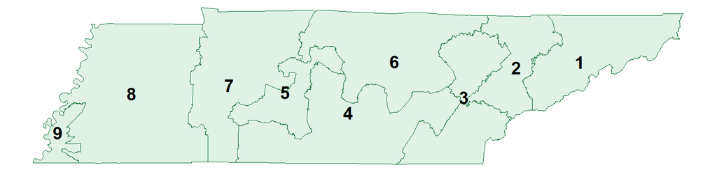

Figure 1: Congressional districts of Tennessee, each labeled by its congressional district number.

```r
districts <- st_make_valid(st_transform(districts, 4269))
names(districts)[names(districts) == attr(districts, "sf_column")] <- "geom"
st_geometry(districts) <- "geom"

# standardize the district id column to "DISTRICT" (names vary by source)
dcol <- c("DISTRICT", "DISTRICT_I", grep("^CD[0-9]+FP$", names(districts), value = TRUE))
dcol <- dcol[dcol %in% names(districts)][1]
districts$DISTRICT <- as.integer(as.character(districts[[dcol]]))

blockgroups <- st_make_valid(st_transform(blockgroups, 4269))
names(blockgroups)[names(blockgroups) == attr(blockgroups, "sf_column")] <- "geom"
st_geometry(blockgroups) <- "geom"

if (have_votes) {
  precincts <- st_make_valid(precincts) |> st_transform(4269)
  names(precincts)[names(precincts) == attr(precincts, "sf_column")] <- "geom"
  st_geometry(precincts) <- "geom"
}

# state aspect ratio (height / width), used to size maps so they do not leave whitespace
.bb <- st_bbox(districts)
map_w   <- 8   # map width in inches
map_asp <- as.numeric((.bb["ymax"] - .bb["ymin"]) /
                      ((.bb["xmax"] - .bb["xmin"]) * cospi(mean(c(.bb["ymin"], .bb["ymax"])) / 180)))
```

### 3.3.2 Compute variables of interest

We compute the percentage of the population 18 years and older that belongs to the group named by `params$group`. For a race such as Black or Asian we select the `P3` variables whose label names that group, counting anyone who identifies with that category alone or in combination with any other race. For Hispanic or Latino, which the census treats as an ethnicity rather than a race, we use the `P4` table instead.

```r
group_label <- params$group   # a P3 race (e.g. Black, Asian) or "Hispanic" from table P4

if (tolower(group_label) == "hispanic") {
  # Hispanic or Latino, population 18 and over (table P4, variable P4_002N)
  minority_vars <- census2020pl_vars |>
    dplyr::filter(name == "P4_002N") |>
    dplyr::select(name, label)
} else {
  # a race category, population 18 and over (table P3, alone or in combination)
  minority_vars <- census2020pl_vars |>
    dplyr::filter(str_detect(name, "^P3"), str_detect(label, group_label)) |>
    dplyr::select(name, label)
}
```

Table 1: Selected census variables for the group of interest.

| Variable | Label |
| --- | --- |
| P3_004N | !!Total:!!Population of one race:!!Black or African American alone |
| P3_011N | !!Total:!!Population of two or more races:!!Population of two races:!!White; Black or African American |
| P3_016N | !!Total:!!Population of two or more races:!!Population of two races:!!Black or African American; American Indian and Alaska Native |
| P3_017N | !!Total:!!Population of two or more races:!!Population of two races:!!Black or African American; Asian |
| P3_018N | !!Total:!!Population of two or more races:!!Population of two races:!!Black or African American; Native Hawaiian and Other Pacific Islander |
| P3_019N | !!Total:!!Population of two or more races:!!Population of two races:!!Black or African American; Some Other Race |
| P3_027N | !!Total:!!Population of two or more races:!!Population of three races:!!White; Black or African American; American Indian and Alaska Native |
| P3_028N | !!Total:!!Population of two or more races:!!Population of three races:!!White; Black or African American; Asian |
| P3_029N | !!Total:!!Population of two or more races:!!Population of three races:!!White; Black or African American; Native Hawaiian and Other Pacific Islander |
| P3_030N | !!Total:!!Population of two or more races:!!Population of three races:!!White; Black or African American; Some Other Race |
| P3_037N | !!Total:!!Population of two or more races:!!Population of three races:!!Black or African American; American Indian and Alaska Native; Asian |
| P3_038N | !!Total:!!Population of two or more races:!!Population of three races:!!Black or African American; American Indian and Alaska Native; Native Hawaiian and Other Pacific Islander |
| P3_039N | !!Total:!!Population of two or more races:!!Population of three races:!!Black or African American; American Indian and Alaska Native; Some Other Race |
| P3_040N | !!Total:!!Population of two or more races:!!Population of three races:!!Black or African American; Asian; Native Hawaiian and Other Pacific Islander |
| P3_041N | !!Total:!!Population of two or more races:!!Population of three races:!!Black or African American; Asian; Some Other Race |
| P3_042N | !!Total:!!Population of two or more races:!!Population of three races:!!Black or African American; Native Hawaiian and Other Pacific Islander; Some Other Race |
| P3_048N | !!Total:!!Population of two or more races:!!Population of four races:!!White; Black or African American; American Indian and Alaska Native; Asian |
| P3_049N | !!Total:!!Population of two or more races:!!Population of four races:!!White; Black or African American; American Indian and Alaska Native; Native Hawaiian and Other Pacific Islander |
| P3_050N | !!Total:!!Population of two or more races:!!Population of four races:!!White; Black or African American; American Indian and Alaska Native; Some Other Race |
| P3_051N | !!Total:!!Population of two or more races:!!Population of four races:!!White; Black or African American; Asian; Native Hawaiian and Other Pacific Islander |
| P3_052N | !!Total:!!Population of two or more races:!!Population of four races:!!White; Black or African American; Asian; Some Other Race |
| P3_053N | !!Total:!!Population of two or more races:!!Population of four races:!!White; Black or African American; Native Hawaiian and Other Pacific Islander; Some Other Race |
| P3_058N | !!Total:!!Population of two or more races:!!Population of four races:!!Black or African American; American Indian and Alaska Native; Asian; Native Hawaiian and Other Pacific Islander |
| P3_059N | !!Total:!!Population of two or more races:!!Population of four races:!!Black or African American; American Indian and Alaska Native; Asian; Some Other Race |
| P3_060N | !!Total:!!Population of two or more races:!!Population of four races:!!Black or African American; American Indian and Alaska Native; Native Hawaiian and Other Pacific Islander; Some Other Race |
| P3_061N | !!Total:!!Population of two or more races:!!Population of four races:!!Black or African American; Asian; Native Hawaiian and Other Pacific Islander; Some Other Race |
| P3_064N | !!Total:!!Population of two or more races:!!Population of five races:!!White; Black or African American; American Indian and Alaska Native; Asian; Native Hawaiian and Other Pacific Islander |
| P3_065N | !!Total:!!Population of two or more races:!!Population of five races:!!White; Black or African American; American Indian and Alaska Native; Asian; Some Other Race |
| P3_066N | !!Total:!!Population of two or more races:!!Population of five races:!!White; Black or African American; American Indian and Alaska Native; Native Hawaiian and Other Pacific Islander; Some Other Race |
| P3_067N | !!Total:!!Population of two or more races:!!Population of five races:!!White; Black or African American; Asian; Native Hawaiian and Other Pacific Islander; Some Other Race |
| P3_069N | !!Total:!!Population of two or more races:!!Population of five races:!!Black or African American; American Indian and Alaska Native; Asian; Native Hawaiian and Other Pacific Islander; Some Other Race |
| P3_071N | !!Total:!!Population of two or more races:!!Population of six races:!!White; Black or African American; American Indian and Alaska Native; Asian; Native Hawaiian and Other Pacific Islander; Some Other… |

For each block group we sum the selected columns into `minority`, copy the 18-and-over total (`P3_001N`) into `Total`, and compute `pctMinority`. `CheckPct` is the share of the population that is either White alone or the minority group, which should be near 100 percent unless other minority groups are large. We also compute the area of each block group for later area-weighted reaggregation.

```r
# fall back to voting-age population if total population is absent (older cached file)
if (!"P1_001N" %in% names(blockgroups)) blockgroups$P1_001N <- blockgroups$P3_001N

blockgroups_calc <- blockgroups |>
  dplyr::filter(!st_is_empty(geom)) |>
  rowwise() |>
  mutate(minority = sum(c_across(all_of(minority_vars$name)))) |>
  ungroup() |>
  mutate(sarea = st_area(geom),
         Total = P3_001N,     # voting-age population (18+), used for composition
         TotalPop = P1_001N,  # all ages, used to size the compact districts
         pctMinority = minority / Total * 100,
         CheckPct = (minority + P3_003N) / Total * 100) |>
  dplyr::select(GEOID, sarea, minority, Total, TotalPop, pctMinority, CheckPct)
```

For the precincts we compute `totV`, the two-party presidential total, and `mpV`, the minority party vote. The majority and minority party designations are state specific, so we choose the minority party automatically as the statewide underdog, the party with fewer total votes.

```r
if (have_votes) {
  # 2024 two-party presidential columns, detected by name
  # (Republican G24PRER*, Democratic G24PRED*)
  rep_cols <- grep("^G24PRER", names(precincts), value = TRUE)
  dem_cols <- grep("^G24PRED", names(precincts), value = TRUE)

  Rtot <- sum(rowSums(st_drop_geometry(precincts)[rep_cols]), na.rm = TRUE)
  Dtot <- sum(rowSums(st_drop_geometry(precincts)[dem_cols]), na.rm = TRUE)
  minority_party <- if (Dtot <= Rtot) "Democratic" else "Republican"
  mp_cols <- if (minority_party == "Democratic") dem_cols else rep_cols

  precincts <- precincts |>
    mutate(totV = rowSums(across(all_of(c(rep_cols, dem_cols)))),
           mpV  = rowSums(across(all_of(mp_cols))),
           sarea = st_area(geom))
}
```

```r
if (have_votes) {
  # Allocate each precinct's votes to intersecting block groups by voting-age population.
  vote_fragments <- st_intersection(
    precincts |>
      mutate(precinct_id = dplyr::row_number()) |>
      dplyr::select(precinct_id, totV, mpV),
    blockgroups_calc |>
      dplyr::select(GEOID, Total, sarea)
  ) |>
    mutate(bg_weight = Total * as.numeric(st_area(geom) / sarea),
           prec_totV = totV,
           prec_mpV = mpV) |>
    group_by(precinct_id) |>
    mutate(weight = bg_weight / sum(bg_weight),
           totV = prec_totV * weight,
           mpV = prec_mpV * weight) |>
    ungroup() |>
    group_by(GEOID) |>
    summarize(totV = sum(totV), mpV = sum(mpV), .groups = "drop")

  blockgroups_calc <- blockgroups_calc |>
    left_join(st_drop_geometry(vote_fragments), by = "GEOID") |>
    mutate(totV = coalesce(totV, 0),
           mpV = coalesce(mpV, 0))
}
```

### 3.3.3 Descriptive statistics (racial and ethnic composition by district)

# Disabled section

Disabled the following code blocks, which need to be:

- consistent with disaggregating voting data into census blocks
- responsive to a decision to be inclusive or exclusive with regards to intersectional racial/ethnic identities
- comprehensive: just summarize all data from blocks simulaneously in one descriptive table

```
race_vars <- c(White = "P3_003N", Black = "P3_004N",
               `Am. Indian / AK Native` = "P3_005N", Asian = "P3_006N",
               `Nat. Hawaiian / Pac. Isl.` = "P3_007N", `Some other race` = "P3_008N",
               `Two or more races` = "P3_009N")
eth_vars <- c(`Hispanic or Latino` = "P4_002N", `Not Hispanic or Latino` = "P4_003N")
vote_vars <- c(`Total Votes` = "totV", `Minority Party Votes` = "mpV")
all_vars <- c(race_vars, eth_vars, vote_vars)

# per-district composition by area-weighted reaggregation of the block groups
bg_race <- blockgroups |>
  dplyr::filter(!st_is_empty(geom)) |>
  mutate(sarea = st_area(geom)) |>
  dplyr::select(sarea, Total = P3_001N, dplyr::all_of(unname(all_vars)))

dist_comp <- st_intersection(bg_race, districts) |>
  st_make_valid() |> st_collection_extract("POLYGON") |>
  dplyr::filter(!st_is_empty(geom)) |>
  mutate(w = as.numeric(st_area(geom) / sarea)) |>
  st_drop_geometry() |>
  group_by(DISTRICT) |>
  summarize(dplyr::across(c(Total, dplyr::all_of(unname(all_vars))), ~ sum(.x * w)),
            .groups = "drop") |>
  arrange(DISTRICT)

# statewide totals
sw <- blockgroups |> st_drop_geometry() |>
  dplyr::summarize(Total = sum(P3_001N),
                   dplyr::across(dplyr::all_of(unname(all_vars)), ~ sum(.x)))

# percentages, statewide row on top
pct <- bind_rows(sw, dplyr::select(dist_comp, -DISTRICT)) |>
  mutate(dplyr::across(dplyr::all_of(unname(all_vars)), ~ round(.x / Total * 100, 1)))
district_labels <- c("Statewide", as.character(dist_comp$DISTRICT))

race_tab <- cbind(District = district_labels, dplyr::select(pct, dplyr::all_of(unname(race_vars))))
names(race_tab) <- c("District", names(race_vars))
race_tab |>
  kbl(caption = "Race composition of the voting-age population by district (%).") |>
  style_tbl() |>
  row_spec(1, bold = TRUE, background = "#EAF0F1") |>
  scroll_box(width = "100%")
```

```
hisp_tab <- cbind(District = district_labels, dplyr::select(pct, dplyr::all_of(unname(eth_vars))))
names(hisp_tab) <- c("District", names(eth_vars))
hisp_tab |>
  kbl(caption = "Hispanic or Latino ethnicity of the voting-age population by district (%).") |>
  style_tbl() |>
  row_spec(1, bold = TRUE, background = "#EAF0F1")
```

### 3.3.4 Dot density map (where the group lives)

# Disabled section

Dot density mapping becomes infeasible with large data and small enumeration areas.

```
set.seed(1)
dot_people <- 1000   # people per dot (voting age); raise this to speed up rendering
bg_dots <- blockgroups |> dplyr::filter(!st_is_empty(geom))

# helper: build one point layer per category column, sampled in proportion to its count
sample_dots <- function(bg, cols) {
  parts <- lapply(names(cols), function(nm) {
    n   <- round(pmax(st_drop_geometry(bg)[[cols[[nm]]]], 0) / dot_people)
    sfc <- st_sample(bg, size = n)
    if (length(sfc) == 0) NULL else st_sf(kind = nm, geometry = sfc)
  })
  out <- do.call(rbind, parts[!vapply(parts, is.null, logical(1))])
  out$kind <- factor(out$kind, levels = names(cols))
  out
}
```

```
{map-dots-group, eval = FALSE,  echo = FALSE, fig.width = map_w, fig.height = map_w * map_asp + 0.6, fig.cap = paste0("Dot density of ", params$group, " and everyone else, ", params$state, ".")}
if (tolower(params$group) == "hispanic") {
  bg_dots$grp <- bg_dots$P4_002N
} else {
  bg_dots$grp <- rowSums(st_drop_geometry(bg_dots)[minority_vars$name], na.rm = TRUE)
}
bg_dots$oth <- pmax(bg_dots$P3_001N - bg_dots$grp, 0)

ggplot() +
  geom_sf(data = sample_dots(bg_dots, setNames(c("grp", "oth"), c(params$group, "Other"))),
          aes(color = kind), size = 0.15, alpha = 0.5) +
  geom_sf(data = districts, fill = NA, color = "grey40", linewidth = 0.3) +
  scale_color_manual(values = setNames(c("#2166ac", "grey75"), c(params$group, "Other")),
                     name = NULL) +
  guides(color = guide_legend(override.aes = list(size = 2, alpha = 1))) +
  labs(subtitle = paste0("1 dot = ", dot_people, " people (voting age)")) +
  theme_void(base_size = 14) +
  theme(legend.position = "bottom", plot.margin = margin(0, 0, 0, 0))
```

# 4 Analysis

## 4.1 District composition by area-weighted reaggregation

We estimate the minority share of each district by area-weighted reaggregation of the block groups. Intersecting the block groups with the districts splits each block group into fragments, one per district it touches. We allocate each block group’s population to its fragments in proportion to area, then sum the fragments by district. We keep the fragments (`race_fragments`) because later steps reuse them. The intersection is made robust by keeping only polygons, repairing invalid geometries, dropping empty results, and casting to single-part polygons.

```r
race_fragments <- st_intersection(blockgroups_calc, districts) |>
  st_make_valid() |>
  st_collection_extract("POLYGON") |>   # drop line/point slivers from planar overlaps
  dplyr::filter(!st_is_empty(geom)) |>
  st_cast("MULTIPOLYGON") |> st_cast("POLYGON") |>
  mutate(awTot    = Total * as.numeric(st_area(geom) / sarea),
         awMinor  = minority * as.numeric(st_area(geom) / sarea),
         awTotPop = TotalPop * as.numeric(st_area(geom) / sarea),
         awtotV = totV * as.numeric(st_area(geom) / sarea),
         awmpV = mpV * as.numeric(st_area(geom) / sarea),
         frag_id  = row_number()) |>
  dplyr::select(DISTRICT, frag_id, sarea,
                Total = awTot,
                minority = awMinor,
                TotalPop = awTotPop,
                totV = awtotV,
                mpV = awmpV)

district_estimates <- race_fragments |>
  st_drop_geometry() |>
  group_by(DISTRICT) |>
  summarize(bgTotal = sum(Total),
            bgMinority = sum(minority),
            totV = sum(totV),
            mpV = sum(mpV),
            .groups = "drop")

districts_join <- districts |>
  left_join(district_estimates, by = "DISTRICT") |>
  mutate(pctMinoritybg = round(bgMinority / bgTotal * 100, 1),
         pctMP = round(mpV / totV * 100, 1))
```

## 4.2 Convex hull composition

The convex hull of a district is the smallest convex shape that contains it, like a rubber band stretched around the district. We build one hull per district and estimate the minority share inside it by the same area-weighted reaggregation, this time intersecting the block groups with the hulls. When precinct data is present we do the same for votes.

```r
d_ch <- districts |>
  dplyr::select(DISTRICT) |>
  st_convex_hull() |>
  mutate(chArea = st_area(geom))

d_ch_est <- st_intersection(blockgroups_calc, d_ch) |>
  st_make_valid() |>
  st_collection_extract("POLYGON") |>
  dplyr::filter(!st_is_empty(geom)) |>
  mutate(awTot   = Total * as.numeric(st_area(geom) / sarea),
         awMinor = minority * as.numeric(st_area(geom) / sarea)) |>
  st_drop_geometry() |>
  group_by(DISTRICT, chArea) |>
  summarize(chTotal = sum(awTot), chMinority = sum(awMinor), .groups = "drop")

if (have_votes) {
  d_ch_estV <- st_intersection(precincts, d_ch) |>
    st_make_valid() |>
    st_collection_extract("POLYGON") |>
    dplyr::filter(!st_is_empty(geom)) |>
    mutate(awTot   = totV * as.numeric(st_area(geom) / sarea),
           awMinor = mpV  * as.numeric(st_area(geom) / sarea)) |>
    st_drop_geometry() |>
    group_by(DISTRICT) |>
    summarize(chtotV = sum(awTot), chmpV = sum(awMinor), .groups = "drop")
}
```

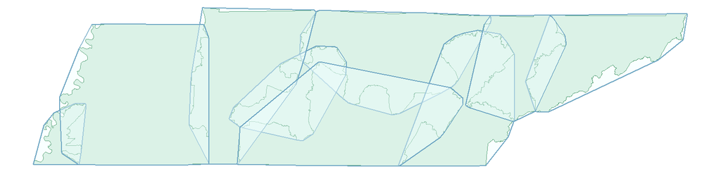

Figure 2: Each district in Tennessee with its convex hull.

## 4.3 Minimum bounding circle composition

```r
# auto-select the NAD83 UTM zone from the districts' centroid longitude
ctr <- suppressWarnings(st_coordinates(st_centroid(st_union(districts))))
mbc_crs <- 26900L + as.integer(floor((ctr[1] + 180) / 6) + 1)

d_mbc <- districts |>
  dplyr::select(DISTRICT) |>
  st_transform(3395) |>
  lwgeom::st_minimum_bounding_circle() |>
  st_transform(4269) |>
  mutate(mbcArea = st_area(geom))

d_mbc_est <- st_intersection(blockgroups_calc, d_mbc) |>
  st_make_valid() |>
  st_collection_extract("POLYGON") |>
  dplyr::filter(!st_is_empty(geom)) |>
  mutate(awTot   = Total * as.numeric(st_area(geom) / sarea),
         awMinor = minority * as.numeric(st_area(geom) / sarea)) |>
  st_drop_geometry() |>
  group_by(DISTRICT, mbcArea) |>
  summarize(mbcTotal = sum(awTot), mbcMinority = sum(awMinor), .groups = "drop")

if (have_votes) {
  d_mbc_estV <- st_intersection(precincts, d_mbc) |>
    st_make_valid() |>
    st_collection_extract("POLYGON") |>
    dplyr::filter(!st_is_empty(geom)) |>
    mutate(awTot   = totV * as.numeric(st_area(geom) / sarea),
           awMinor = mpV  * as.numeric(st_area(geom) / sarea)) |>
    st_drop_geometry() |>
    group_by(DISTRICT) |>
    summarize(mbctotV = sum(awTot), mbcmpV = sum(awMinor), .groups = "drop")
}
```

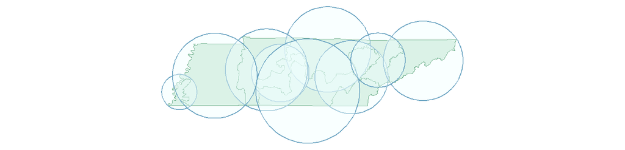

Figure 3: Each district in Tennessee with its minimum bounding circle.

## 4.4 Compactness scores and the Cdiff computation

We now compare each district to its compact reference shapes. Three compactness scores describe how regular a district’s shape is. The Polsby-Popper score uses the district area and perimeter, the convex hull ratio compares the district area to its hull area, and the Reock score compares the district area to its minimum bounding circle. The Cdiff scores compare composition instead of shape. `chDiff` is the district’s minority percentage minus the minority percentage of its convex hull, and `mbcDiff` is the same for the minimum bounding circle. A positive Cdiff suggests packing and a negative Cdiff suggests cracking. When precinct data is present we compute the same differences for the minority party vote as `chDiffV` and `mbcDiffV`.

```r
districts_results <- districts_join |>
  left_join(d_ch_est, by = "DISTRICT") |>
  mutate(chPct = round(chMinority / chTotal * 100, 1),
         chDiff = pctMinoritybg - chPct, chAbsDiff = abs(chDiff)) |>
  left_join(d_mbc_est, by = "DISTRICT") |>
  mutate(mbcPct = round(mbcMinority / mbcTotal * 100, 1),
         mbcDiff = pctMinoritybg - mbcPct, mbcAbsDiff = abs(mbcDiff))

if (have_votes) {
  districts_results <- districts_results |>
    left_join(d_ch_estV, by = "DISTRICT") |>
    mutate(chPctV = round(chmpV / chtotV * 100, 1),
           chDiffV = pctMP - chPctV, chAbsDiffV = abs(chDiffV)) |>
    left_join(d_mbc_estV, by = "DISTRICT") |>
    mutate(mbcPctV = round(mbcmpV / mbctotV * 100, 1),
           mbcDiffV = pctMP - mbcPctV, mbcAbsDiffV = abs(mbcDiffV))
}

# Polsby-Popper mixes area and perimeter, so compute it in the projected CRS (meters).
# The hull and circle scores are unit-free ratios, so geographic areas are fine there.
dproj <- st_transform(st_geometry(districts_results), mbc_crs)
districts_results <- districts_results |>
  mutate(darea = st_area(geom),
         compact_shp  = round(as.numeric((4 * pi * st_area(dproj)) /
                                         st_length(st_cast(dproj, "MULTILINESTRING"))^2), 2),
         compact_hull = round(as.numeric(darea / chArea), 2),
         compact_circ = round(as.numeric(darea / mbcArea), 2))
```

Table 2 reports the three compactness scores for each district as a shape reference. They describe only how regular each district’s outline is, which is a separate question from the composition that the Cdiff scores address. A score near 1 is compact and a score near 0 is stringy.

Table 2: Shape-compactness scores by district, Tennessee (near 1 is compact, near 0 is stringy).

| District | Polsby-Popper | Convex hull ratio | Reock |
| --- | --- | --- | --- |
| 1 | 0.28 | 0.81 | 0.32 |
| 2 | 0.17 | 0.63 | 0.41 |
| 3 | 0.16 | 0.65 | 0.34 |
| 4 | 0.20 | 0.70 | 0.27 |
| 5 | 0.13 | 0.56 | 0.28 |
| 6 | 0.25 | 0.77 | 0.37 |
| 7 | 0.27 | 0.78 | 0.40 |
| 8 | 0.30 | 0.87 | 0.58 |
| 9 | 0.12 | 0.62 | 0.29 |

## 4.5 Compact population center composition

We add a third compact reference shape. For each district we find the population-weighted mean center of its residents and grow a compact district outward from that center, adding the nearest population until it reaches the target size. The target size is the state’s total population divided by the number of districts, because redistricting equalizes total population. Centers and distances are computed in a projected coordinate system so that distances are in meters. As with the other shapes, composition is measured with the voting-age population.

```r
race_fragments |> st_write(
  here(output_dir, "race_frags.gpkg"),
  append = FALSE
)
```

```
## Deleting layer `race_frags' using driver `GPKG'
## Writing layer `race_frags' to data source
##   `C:/git/josephholler/OR-Gerrymander-Alabama/data/derived/private/Tennessee/race_frags.gpkg' using driver `GPKG'
## Writing 189759 features with 8 fields and geometry type Polygon.
```

```r
n_districts <- dplyr::n_distinct(districts$DISTRICT)
idealpop <- sum(blockgroups_calc$TotalPop) / n_districts

# fragment centroids in the projected CRS (meters)
frag_pts <- race_fragments |> st_centroid() |> st_transform(mbc_crs)
frag_xy  <- st_coordinates(frag_pts)
frag_tab <- st_drop_geometry(frag_pts) |>
  mutate(x = frag_xy[, 1], y = frag_xy[, 2])

# population-weighted mean center of each district
centers <- frag_tab |>
  group_by(DISTRICT) |>
  summarize(cx = sum(x * TotalPop) / sum(TotalPop),
            cy = sum(y * TotalPop) / sum(TotalPop), .groups = "drop") |>
  rename(cpcDistrict = DISTRICT)

# for each center, take the nearest fragments until the target population is reached
cpc_assign <- frag_tab |>
  dplyr::select(frag_id, DISTRICT, x, y, TotalPop, Total, minority, totV, mpV) |>
  cross_join(centers) |>
  mutate(dist = sqrt((x - cx)^2 + (y - cy)^2)) |>
  arrange(cpcDistrict, dist) |>
  group_by(cpcDistrict) |>
  mutate(cumpop = cumsum(TotalPop)) |>
  dplyr::filter(cumpop <= idealpop) |>
  ungroup()
```

Create one spatial layer of locations and their status *vis-a-vis* cpc’s.

```r
# join cpc assignment table to race_fragments spatial features
cpc_fragments <- race_fragments |>
  left_join(dplyr::select(cpc_assign, frag_id, cpcDistrict), by = "frag_id")

# identity fragments are inside of both the district and it's cpc
cpc_identity <- cpc_fragments |> filter(DISTRICT == cpcDistrict) |>
  mutate(cpc_type = 'identity')

# captured fragments are inside the district, but not it's cpc, as if the
# compact district boundaries were stretched out to capture these areas
cpc_capture <- race_fragments |>
  anti_join(st_drop_geometry(cpc_identity), by = "frag_id") |>
  mutate(cpc_type = 'captured')

# excluded fragments are outside the district, but inside it's cpc, as if
# the compact district boundaries were shrunk / contorted to exclude these areas
cpc_excluded <- cpc_fragments |>
  filter(DISTRICT != cpcDistrict) |>
  mutate(cpc_type = 'excluded')

# count how many cpc's overlapped
cpc_excluded_n <- cpc_excluded |>
  st_drop_geometry() |>
  group_by(frag_id) |>
  summarize(excluded_count = n(), .groups ="drop")

# join the count back to the cpc_excluded fragments
cpc_excluded <- cpc_excluded |>
  left_join(cpc_excluded_n, by = "frag_id")

# merge all three cases of CPCs together and save
cpc_fragments <- bind_rows(cpc_identity, cpc_capture, cpc_excluded)

cpc_fragments |> st_write(here(output_dir, "cpc_fragments.gpkg"),
                          append = FALSE)
```

```
## Deleting layer `cpc_fragments' using driver `GPKG'
## Writing layer `cpc_fragments' to data source
##   `C:/git/josephholler/OR-Gerrymander-Alabama/data/derived/private/Tennessee/cpc_fragments.gpkg' using driver `GPKG'
## Writing 228919 features with 11 fields and geometry type Polygon.
```

Summarize CPC results at the district level

```r
# composition inside each compact population-center district (voting-age)
cpc_est <- cpc_assign |>
  group_by(cpcDistrict) |>
  summarize(cpcTotal = sum(Total),
            cpcMinority = sum(minority),
            cpcIdealPop = sum(TotalPop),
            cpctotV = sum(totV),
            cpcmpV = sum(mpV)) |>
  mutate(cpcPct = round(cpcMinority / cpcTotal * 100, 1),
         cpcPctV = round(cpcmpV / cpctotV * 100, 1))

cpc_cases <- cpc_fragments |>
  group_by(DISTRICT, cpcDistrict, cpc_type) |>
  summarize(cpcTotal = sum(Total),
            cpcTargetPop = sum(TotalPop),
            cpcMinority = sum(minority),
            cpctotV = sum(totV),
            cpcmpV = sum(mpV)) |>
  ungroup()

cpc_cases |> st_write(here(output_dir, "cpc_cases.gpkg"),
                      append = FALSE)
```

```
## Deleting layer `cpc_cases' using driver `GPKG'
## Writing layer `cpc_cases' to data source
##   `C:/git/josephholler/OR-Gerrymander-Alabama/data/derived/private/Tennessee/cpc_cases.gpkg' using driver `GPKG'
## Writing 37 features with 8 fields and geometry type Unknown (any).
```

```r
cpcd_identity <- cpc_cases |>
  filter(cpc_type == 'identity') |>
  st_drop_geometry() |>
  mutate(cpcidTotal = cpcTotal,
         cpcidMinority = cpcMinority,
         cpcidIdealPop = cpcTargetPop,
         cpcidPctMinority = round(cpcidMinority / cpcidTotal * 100, 1),
         cpcidtotV = cpctotV,
         cpcidmpV = cpcmpV,
         cpcidPctV = round(cpcidmpV / cpcidtotV * 100, 1)) |>
  select(DISTRICT, starts_with("cpcid"))

cpcd_captured <- cpc_cases |>
  filter(cpc_type == 'captured') |>
  st_drop_geometry() |>
  mutate(cpccaTotal = cpcTotal,
         cpccaMinority = cpcMinority,
         cpccaIdealPop = cpcTargetPop,
         cpccaPctMinority = round(cpccaMinority / cpccaTotal * 100, 1),
         cpccatotV = cpctotV,
         cpccampV = cpcmpV,
         cpccaPctV = round(cpccampV / cpccatotV * 100, 1)) |>
  select(DISTRICT, starts_with("cpcca"))

cpcd_excluded <- cpc_cases |>
  filter(cpc_type == 'excluded') |>
  st_drop_geometry() |>
  group_by(cpcDistrict) |>
  summarize(cpcexTotal = sum(cpcTotal),
            cpcexMinority = sum(cpcMinority),
            cpcexIdealPop = sum(cpcTargetPop),
            cpcextotV = sum(cpctotV),
            cpcexmpV = sum(cpcmpV)) |>
  mutate(DISTRICT = cpcDistrict,
         cpcexPctMinority = round(cpcexMinority / cpcexTotal * 100, 1),
         cpcexPctV = round(cpcexmpV / cpcextotV * 100, 1)) |>
  select(DISTRICT, starts_with("cpcex"))

# dissolve the assigned fragments into compact population-center district shapes
cpc_districts <- bind_rows(cpc_excluded, cpc_identity) |>
  group_by(cpcDistrict) |>
  summarize() |>
  left_join(cpc_est, by="cpcDistrict")

cpc_districts |> st_write(here(output_dir, "cpc_shapes.gpkg"),
                      append = FALSE)
```

```
## Deleting layer `cpc_shapes' using driver `GPKG'
## Writing layer `cpc_shapes' to data source
##   `C:/git/josephholler/OR-Gerrymander-Alabama/data/derived/private/Tennessee/cpc_shapes.gpkg' using driver `GPKG'
## Writing 9 features with 8 fields and geometry type Multi Polygon.
```

```r
districts_results <- districts_results |>
  left_join(cpc_est, by = c("DISTRICT" = "cpcDistrict")) |>
  left_join(cpcd_identity, by = "DISTRICT") |>
  left_join(cpcd_captured, by = "DISTRICT") |>
  left_join(cpcd_excluded, by = "DISTRICT")

districts_results <- districts_results |>
  mutate(cpcDiff = pctMinoritybg - cpcPct, cpcAbsDiff = abs(cpcDiff),
         cpcIdentityPct = cpcidTotal / bgTotal * 100,
         cpcCapturePctDiff = cpccaPctMinority - cpcidPctMinority,
         cpcExcludePctDiff = cpcexPctMinority - cpcidPctMinority,
         cpcDiffV = pctMP - cpcPctV,
         cpcAbsDiffV = abs(cpcDiffV),
         cpcIdentityPctV = cpcidtotV / totV * 100,
         cpcCapturePctDiffV = cpccaPctV - cpcidPctV,
         cpcExcludePctDiffV = cpcexPctV - cpcidPctV,
         )
```

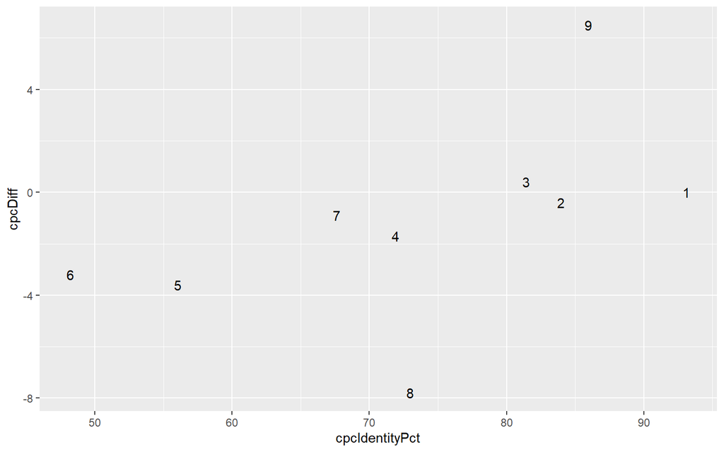

```r
ggplot(data = districts_results, mapping = aes(x = cpcIdentityPct, y = cpcDiff)) +
  geom_text(aes(label = DISTRICT))
```

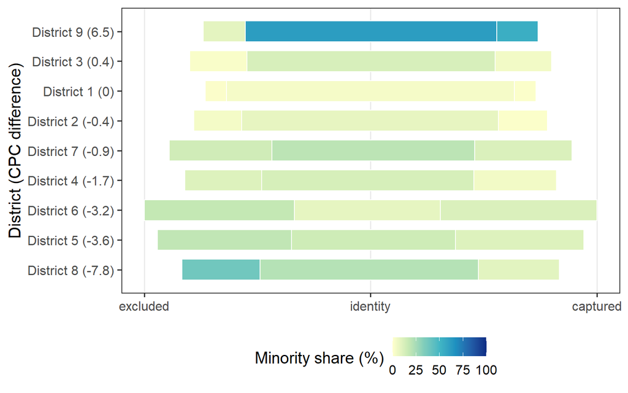

```r
districts_cpc_viz <- districts_results |> st_drop_geometry() |>
  dplyr::select(DISTRICT, cpcDiff, cpcexTotal, cpcidTotal, cpccaTotal,
                cpcexPctMinority, cpcidPctMinority, cpccaPctMinority,
                cpcIdentityPct) |>
  arrange(desc(cpcDiff), DISTRICT) |>
  mutate(rank = row_number(),
         district_label = paste0("District ", DISTRICT, " (", round(cpcDiff, 1), ")")) |>
  pivot_longer(cols = c(cpcexTotal, cpcidTotal, cpccaTotal),
               names_to = "segment", values_to = "width") |>
  mutate(pct_minority = case_when(
    segment == "cpcexTotal" ~ cpcexPctMinority,
    segment == "cpcidTotal" ~ cpcidPctMinority,
    segment == "cpccaTotal" ~ cpccaPctMinority
  ),
  segment = factor(segment,
                   levels = c("cpcexTotal", "cpcidTotal", "cpccaTotal"))) |>
  group_by(DISTRICT) |>
  arrange(segment, .by_group = TRUE) |>
  mutate(total_width = sum(width),
         xmin = -total_width / 2 + cumsum(width) - width,
         xmax = -total_width / 2 + cumsum(width)) |>
  ungroup()

cpc_viz_extent <- max(districts_cpc_viz$total_width, na.rm = TRUE) / 2

ggplot(districts_cpc_viz,
       aes(y = rank, xmin = xmin, xmax = xmax,
           ymin = rank - 0.35, ymax = rank + 0.35,
           fill = pct_minority)) +
  geom_rect(color = "white", linewidth = 0.4) +
  geom_text(data = dplyr::filter(districts_cpc_viz, segment == "cpcidTotal"),
            aes(x = (xmin + xmax) / 2,
                label = paste0(round(cpcIdentityPct, 1), "%")),
            inherit.aes = FALSE, y = districts_cpc_viz$rank[
              districts_cpc_viz$segment == "cpcidTotal"],
            color = "white", fontface = "bold") +
  scale_y_reverse(breaks = unique(districts_cpc_viz$rank),
                  labels = districts_cpc_viz$district_label[match(
                    unique(districts_cpc_viz$rank), districts_cpc_viz$rank)]) +
  scale_x_continuous(breaks = c(-cpc_viz_extent, 0, cpc_viz_extent),
                     labels = c("excluded", "identity", "captured")) +
  scale_fill_distiller(palette = "YlGnBu", direction = 1,
                       limits = c(0, 100), name = "Minority share (%)") +
  labs(x = NULL,
       y = "District (CPC difference)") +
  theme_bw(base_size = 15) +
  theme(panel.grid.major.y = element_blank(),
        panel.grid.minor = element_blank(),
        legend.position = "bottom")
```

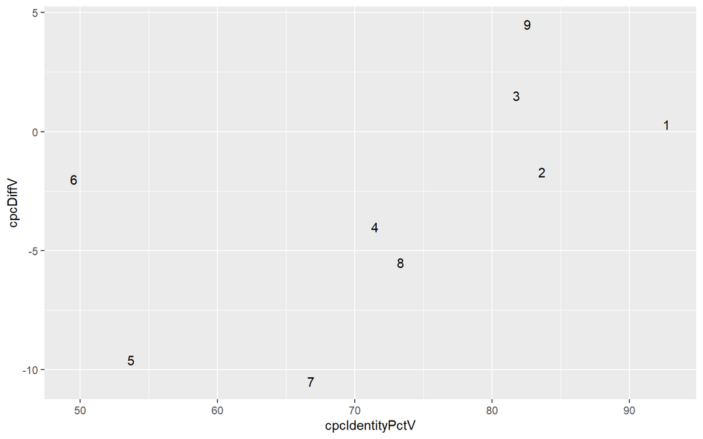

```r
ggplot(data = districts_results, mapping = aes(x = cpcIdentityPctV, y = cpcDiffV)) +
  geom_text(aes(label = DISTRICT))
```

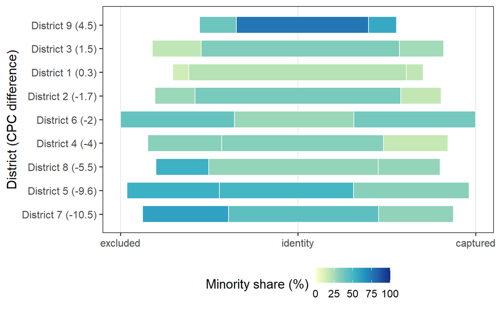

```r
districts_cpc_viz <- districts_results |> st_drop_geometry() |>
  dplyr::select(DISTRICT, cpcDiffV, cpcextotV, cpcidtotV, cpccatotV,
                cpcexPctV, cpcidPctV, cpccaPctV,
                cpcIdentityPctV) |>
  arrange(desc(cpcDiffV), DISTRICT) |>
  mutate(rank = row_number(),
         district_label = paste0("District ", DISTRICT, " (", round(cpcDiffV, 1), ")")) |>
  pivot_longer(cols = c(cpcextotV, cpcidtotV, cpccatotV),
               names_to = "segment", values_to = "width") |>
  mutate(pct_minority = case_when(
    segment == "cpcextotV" ~ cpcexPctV,
    segment == "cpcidtotV" ~ cpcidPctV,
    segment == "cpccatotV" ~ cpccaPctV
  ),
  segment = factor(segment,
                   levels = c("cpcextotV", "cpcidtotV", "cpccatotV"))) |>
  group_by(DISTRICT) |>
  arrange(segment, .by_group = TRUE) |>
  mutate(total_width = sum(width),
         xmin = -total_width / 2 + cumsum(width) - width,
         xmax = -total_width / 2 + cumsum(width)) |>
  ungroup()

cpc_viz_extent <- max(districts_cpc_viz$total_width, na.rm = TRUE) / 2

ggplot(districts_cpc_viz,
       aes(y = rank, xmin = xmin, xmax = xmax,
           ymin = rank - 0.35, ymax = rank + 0.35,
           fill = pct_minority)) +
  geom_rect(color = "white", linewidth = 0.4) +
  geom_text(data = dplyr::filter(districts_cpc_viz, segment == "cpcidTotV"),
            aes(x = (xmin + xmax) / 2,
                label = paste0(round(cpcIdentityPctV, 1), "%")),
            inherit.aes = FALSE, y = districts_cpc_viz$rank[
              districts_cpc_viz$segment == "cpcidTotV"],
            color = "white", fontface = "bold") +
  scale_y_reverse(breaks = unique(districts_cpc_viz$rank),
                  labels = districts_cpc_viz$district_label[match(
                    unique(districts_cpc_viz$rank), districts_cpc_viz$rank)]) +
  scale_x_continuous(breaks = c(-cpc_viz_extent, 0, cpc_viz_extent),
                     labels = c("excluded", "identity", "captured")) +
  scale_fill_distiller(palette = "YlGnBu", direction = 1,
                       limits = c(0, 100), name = "Minority share (%)") +
  labs(x = NULL,
       y = "District (CPC difference)") +
  theme_bw(base_size = 15) +
  theme(panel.grid.major.y = element_blank(),
        panel.grid.minor = element_blank(),
        legend.position = "bottom")
```

```r
districts_results |> st_write(here(output_dir, "district_results.gpkg"),
                              append = FALSE)
```

```
## Deleting layer `district_results' using driver `GPKG'
## Writing layer `district_results' to data source
##   `C:/git/josephholler/OR-Gerrymander-Alabama/data/derived/private/Tennessee/district_results.gpkg' using driver `GPKG'
## Writing 9 features with 80 fields and geometry type Unknown (any).
```

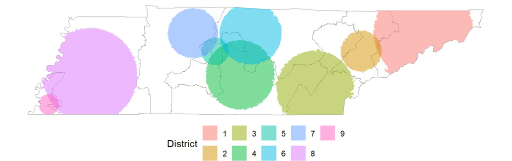

Figure 4: Compact population-center districts over the actual districts, Tennessee.

```r
districts_results |>
  st_drop_geometry() |>
  write_csv(here(output_dir, "district_results.csv"))
```

# 5 Results

## 5.1 Composition difference (Cdiff) table

We report the composition difference two ways, first for the minority party vote and then for the group population, matching the order of the figures. Tables 3 and 4 hold the numeric core of the analysis, and every figure below draws from these numbers. Each row is a district. `pctMinoritybg` is the group’s share of the actual district, and `chPct`, `mbcPct`, and `cpcPct` are the group’s share inside the convex hull, the minimum bounding circle, and the compact population center. `chDiff`, `mbcDiff`, and `cpcDiff` are the actual share minus each of those, so a positive value is packing and a negative value is cracking. To read it, scan the three Cdiff columns for each district. A district with large positive values across all three is strongly packed, and one with large negative values across all three is strongly cracked. Values near zero mean the shape does not move the composition much. When the three columns disagree in sign, the result depends on the reference shape, which is itself worth noting. When precinct data is loaded, the partisan table repeats the same calculation for the minority party vote, with `pctMP` the party’s share of the actual district and `chDiffV`, `mbcDiffV`, and `cpcDiffV` the differences from each reference shape. Shape compactness is a separate question, reported in Table 2. The full result, including every column, is written to a CSV file.

Table 3: Cdiff by district for the minority party vote, Tennessee.

| DISTRICT | pctMP | Convex hull chPctV | Convex hull chDiffV | Min. bounding circle mbcPctV | Min. bounding circle mbcDiffV | Compact pop. center cpcPctV | Compact pop. center cpcDiffV |
| --- | --- | --- | --- | --- | --- | --- | --- |
| 1 | 20.8 | 20.5 | 0.3 | 20.5 | 0.3 | 20.5 | 0.3 |
| 2 | 32.8 | 30.1 | 2.7 | 28.7 | 4.1 | 34.5 | -1.7 |
| 3 | 31.8 | 31.8 | 0.0 | 30.5 | 1.3 | 30.3 | 1.5 |
| 4 | 27.9 | 28.8 | -0.9 | 36.1 | -8.2 | 31.9 | -4.0 |
| 5 | 40.9 | 42.8 | -1.9 | 41.0 | -0.1 | 50.5 | -9.6 |
| 6 | 32.2 | 35.8 | -3.6 | 34.9 | -2.7 | 34.2 | -2.0 |
| 7 | 38.7 | 41.9 | -3.2 | 38.7 | 0.0 | 49.2 | -10.5 |
| 8 | 28.9 | 34.7 | -5.8 | 37.6 | -8.7 | 34.4 | -5.5 |
| 9 | 71.7 | 62.1 | 9.6 | 58.6 | 13.1 | 67.2 | 4.5 |

Note.  
Cdiff is the actual district’s share minus the reference share. Positive suggests packing and negative suggests cracking.

Table 4: Cdiff by district for the Black population, Tennessee.

| DISTRICT | pctMinoritybg | Convex hull chPct | Convex hull chDiff | Min. bounding circle mbcPct | Min. bounding circle mbcDiff | Compact pop. center cpcPct | Compact pop. center cpcDiff |
| --- | --- | --- | --- | --- | --- | --- | --- |
| 1 | 2.7 | 2.7 | 0.0 | 2.7 | 0.0 | 2.7 | 0.0 |
| 2 | 6.3 | 5.3 | 1.0 | 5.0 | 1.3 | 6.7 | -0.4 |
| 3 | 10.5 | 8.1 | 2.4 | 7.4 | 3.1 | 10.1 | 0.4 |
| 4 | 9.9 | 8.9 | 1.0 | 12.3 | -2.4 | 11.6 | -1.7 |
| 5 | 12.7 | 14.2 | -1.5 | 14.6 | -1.9 | 16.3 | -3.6 |
| 6 | 9.4 | 13.5 | -4.1 | 12.6 | -3.2 | 12.6 | -3.2 |
| 7 | 16.7 | 15.1 | 1.6 | 14.4 | 2.3 | 17.6 | -0.9 |
| 8 | 17.7 | 23.7 | -6.0 | 28.1 | -10.4 | 25.5 | -7.8 |
| 9 | 60.3 | 50.7 | 9.6 | 48.6 | 11.7 | 53.8 | 6.5 |

Note.  
Cdiff is the actual district’s share minus the reference share. Positive suggests packing and negative suggests cracking.

```r
districts_results |> st_drop_geometry() |>
  write_csv(file.path(output_dir, "district_results.csv"))
```

## 5.2 Interpreting the composition difference (Cdiff)

Our approach asks a single question, whether a district’s shape changes who it represents. Rather than judging a district by how irregular it looks, it compares the composition of the actual district to the composition of a compact reference version of that same district. The reference can be the convex hull, the minimum bounding circle, or the compact population center. The metric is the difference between the two compositions.

$$C_{diff} = C_{district} - C_{reference}$$

Here $C_{district}$ is the minority percentage inside the actual district and $C_{reference}$ is the minority percentage inside the compact reference shape. `chDiff`, `mbcDiff`, and `cpcDiff` apply this formula to the convex hull, the minimum bounding circle, and the compact population center. When precinct data is present, `chDiffV`, `mbcDiffV`, and `cpcDiffV` apply the same idea to the minority party vote.

There are three cases to read. When $C_{diff}$ is strongly positive, the actual district holds a higher share of the group than its compact reference, which may suggest packing, especially where the district is already majority-minority and the group is over-represented relative to the compact shape. When $C_{diff}$ is strongly negative, the actual district holds a lower share than its compact reference, which suggests cracking, dilution, or the exclusion of nearby group members. When $C_{diff}$ is close to zero, the irregular shape does not meaningfully change the group’s composition, so the district may look non-compact while its shape does not appear to distort racial or partisan representation.

In the figures that follow, the reading is based on the distance between the actual district (the black point) and the compact-shape estimates. The black point to the right of the others points toward packing, and to the left points toward cracking. As you read the table and figures, consider which districts show the largest gap between the actual composition and the compact-shape composition, which appear potentially packed, which appear potentially cracked or diluted, and which stay similar across all geometries.

## 5.3 Composition by district and reference shape

Figure 5 has one panel per district. Within a panel, the row labeled Minority Population (%) is the racial or ethnic composition, and the row labeled Minority Party Vote (%) is the partisan composition. Minority Population is the share of the voting-age population that belongs to the group set by `params$group`. Minority Party Vote is the share of the two-party presidential vote won by the statewide minority party. The vote row appears only when precinct data is loaded.

Each row carries four points, one for the actual district and one for each compact reference shape. Black dots are the composition of the actual district. Green dots are the composition inside its convex hull. Purple dots are the composition inside its minimum bounding circle. Orange dots are the composition inside its compact population center. The distance from the black dot to each colored dot is that reference’s Cdiff.

To read it, go left to right along each row. When the black point sits to the right of the colored points, the actual district holds more of the group than its compact references, which points to packing. When it sits to the left, the district holds less, which points to cracking. When it sits on top of the colored points, the shape barely changes the composition. When the colored points fall on both sides of the black point, the three methods disagree, so read that district with care. The dashed line at 50 percent marks a majority. We do not print the Cdiff numbers on the plot to keep it readable, so read the exact values from the Cdiff table above.

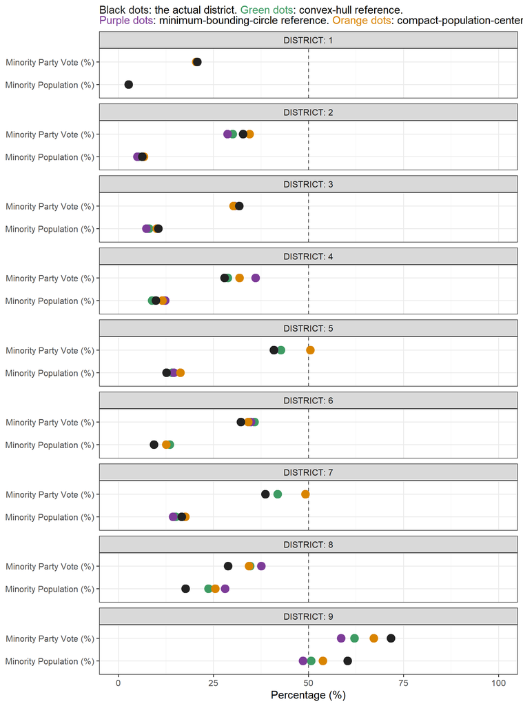

Figure 5: Composition by district and reference shape, Tennessee.

## 5.4 Composition difference (Cdiff) by district

We show the Cdiff two ways, first as bars for the exact size and ranking, then as maps for the spatial pattern.

### 5.4.1 Cdiff bar chart by district and reference shape

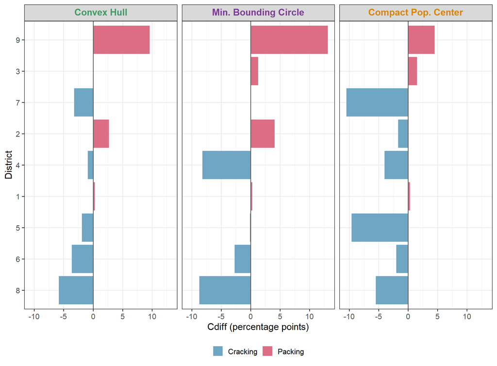

Figure 6: Cdiff by district for the minority party vote, by reference shape, Tennessee.

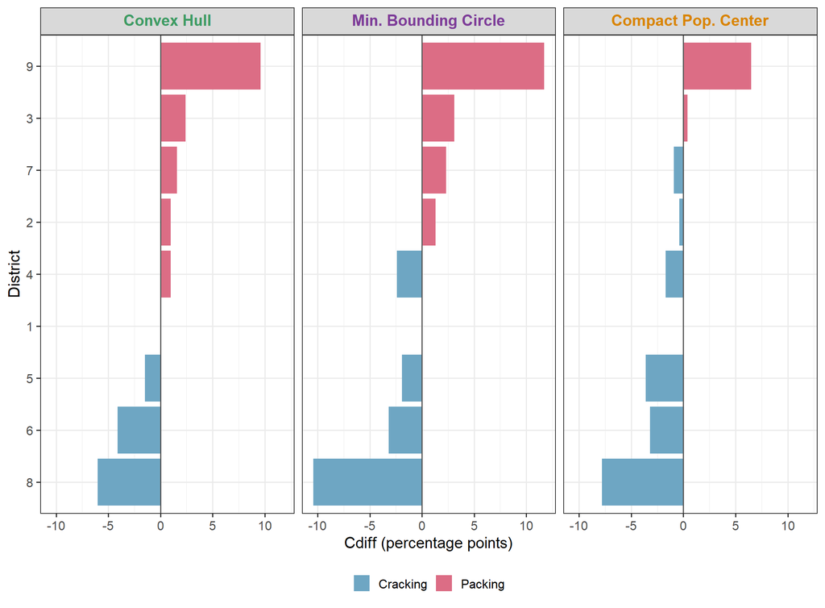

Figure 7: Cdiff by district for the Black population, by reference shape, Tennessee.

### 5.4.2 Cdiff choropleth map by district

Figures 8 and 9 draw the same Cdiff on the district map, so the spatial pattern is visible. Each district is shaded by its Cdiff, red for packed and blue for cracked, with each district number labeled. The three panels are the three reference shapes, side by side, in the same order as the bar chart. As with the bars, the partisan map comes first and the racial map below it. To read it, find a district by its number and compare its color across the three panels. A district that is red in all three panels is robustly packed, and one that is blue in all three is robustly cracked. A district that changes color between panels is a case where the choice of reference shape matters.

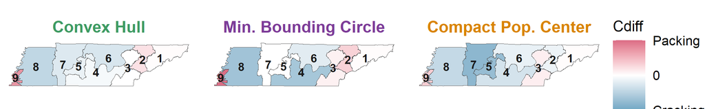

Figure 8: Cdiff mapped for the minority party vote, by reference shape, Tennessee.

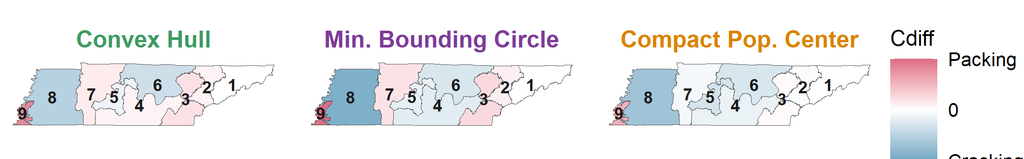

Figure 9: Cdiff mapped for the Black population, by reference shape, Tennessee.